# Part A

# Part B

```python
# Import all the libraries needed to load the dataset and visualize it
import numpy as np
import pandas as pd
import matplotlib.pyplot as plt
import seaborn as sns
```

```python
# Configure for any default setting of any library
%matplotlib inline
sns.set(style='darkgrid', palette='deep', font='sans-serif', font_scale=1.3, color_codes=True)
```

Load the Dataset

```python
basketball = pd.read_csv('DS+-+Part2+-+Basketball (1).csv')
```

```python
basketball.head()
```

|  | Team | Tournament | Score | PlayedGames | WonGames | DrawnGames | LostGames | BasketScored | BasketGiven | TournamentChampion | Runner-up | TeamLaunch | HighestPositionHeld |
| --- | --- | --- | --- | --- | --- | --- | --- | --- | --- | --- | --- | --- | --- |
| 0 | Team 1 | 86 | 4385 | 2762 | 1647 | 552 | 563 | 5947 | 3140 | 33 | 23 | 1929 | 1 |
| 1 | Team 2 | 86 | 4262 | 2762 | 1581 | 573 | 608 | 5900 | 3114 | 25 | 25 | 1929 | 1 |
| 2 | Team 3 | 80 | 3442 | 2614 | 1241 | 598 | 775 | 4534 | 3309 | 10 | 8 | 1929 | 1 |
| 3 | Team 4 | 82 | 3386 | 2664 | 1187 | 616 | 861 | 4398 | 3469 | 6 | 6 | 1931to32 | 1 |
| 4 | Team 5 | 86 | 3368 | 2762 | 1209 | 633 | 920 | 4631 | 3700 | 8 | 7 | 1929 | 1 |

```python
basketball.tail()
```

|  | Team | Tournament | Score | PlayedGames | WonGames | DrawnGames | LostGames | BasketScored | BasketGiven | TournamentChampion | Runner-up | TeamLaunch | HighestPositionHeld |
| --- | --- | --- | --- | --- | --- | --- | --- | --- | --- | --- | --- | --- | --- |
| 56 | Team 57 | 1 | 34 | 38 | 8 | 10 | 20 | 38 | 66 | - | - | 2009-10 | 20 |
| 57 | Team 58 | 1 | 22 | 30 | 7 | 8 | 15 | 37 | 57 | - | - | 1956-57 | 16 |
| 58 | Team 59 | 1 | 19 | 30 | 7 | 5 | 18 | 51 | 85 | - | - | 1951~52 | 16 |
| 59 | Team 60 | 1 | 14 | 30 | 5 | 4 | 21 | 34 | 65 | - | - | 1955-56 | 15 |
| 60 | Team 61 | 1 | - | - | - | - | - | - | - | - | - | 2017~18 | 9 |

```python
basketball.shape
```

```
(61, 13)
```

```python
basketball.info()
```

```
<class 'pandas.core.frame.DataFrame'>
RangeIndex: 61 entries, 0 to 60
Data columns (total 13 columns):
 #   Column               Non-Null Count  Dtype
---  ------               --------------  -----
 0   Team                 61 non-null     object
 1   Tournament           61 non-null     int64
 2   Score                61 non-null     object
 3   PlayedGames          61 non-null     object
 4   WonGames             61 non-null     object
 5   DrawnGames           61 non-null     object
 6   LostGames            61 non-null     object
 7   BasketScored         61 non-null     object
 8   BasketGiven          61 non-null     object
 9   TournamentChampion   61 non-null     object
 10  Runner-up            61 non-null     object
 11  TeamLaunch           61 non-null     object
 12  HighestPositionHeld  61 non-null     int64
dtypes: int64(2), object(11)
memory usage: 6.3+ KB
```

Observations

This dataset contains 61 observations with 13 independant attribues All columns are of type string where as only Tournament and HighestPositionHeld are of type integer There are No null/missing values present in the dataset

Data Cleaning

```python
# Replacae all '-' with 0
basketball.replace(to_replace='-', value=0, inplace=True)

# Correction for TeamLaunch column
basketball['TeamLaunch'] = basketball['TeamLaunch'].apply(lambda year: str(year)[:4])
```

```python
# Convert the datatype of all columns to integer except for TeamName
columns = basketball.columns
basketball[columns[1:]] = basketball[columns[1:]].astype('int64')
basketball.info()
```

```
<class 'pandas.core.frame.DataFrame'>
RangeIndex: 61 entries, 0 to 60
Data columns (total 13 columns):
 #   Column               Non-Null Count  Dtype
---  ------               --------------  -----
 0   Team                 61 non-null     object
 1   Tournament           61 non-null     int64
 2   Score                61 non-null     int64
 3   PlayedGames          61 non-null     int64
 4   WonGames             61 non-null     int64
 5   DrawnGames           61 non-null     int64
 6   LostGames            61 non-null     int64
 7   BasketScored         61 non-null     int64
 8   BasketGiven          61 non-null     int64
 9   TournamentChampion   61 non-null     int64
 10  Runner-up            61 non-null     int64
 11  TeamLaunch           61 non-null     int64
 12  HighestPositionHeld  61 non-null     int64
dtypes: int64(12), object(1)
memory usage: 6.3+ KB
```

```python
basketball.describe()
```

|  | Tournament | Score | PlayedGames | WonGames | DrawnGames | LostGames | BasketScored | BasketGiven | TournamentChampion | Runner-up | TeamLaunch | HighestPositionHeld |
| --- | --- | --- | --- | --- | --- | --- | --- | --- | --- | --- | --- | --- |
| count | 61.000000 | 61.000000 | 61.000000 | 61.000000 | 61.000000 | 61.000000 | 61.000000 | 61.000000 | 61.000000 | 61.000000 | 61.000000 | 61.000000 |
| mean | 24.000000 | 901.426230 | 796.819672 | 303.967213 | 188.934426 | 303.754098 | 1140.344262 | 1140.229508 | 1.426230 | 1.409836 | 1958.918033 | 7.081967 |
| std | 26.827225 | 1134.899121 | 876.282765 | 406.991030 | 201.799477 | 294.708594 | 1506.740211 | 1163.710766 | 5.472535 | 4.540107 | 27.484114 | 5.276663 |
| min | 1.000000 | 0.000000 | 0.000000 | 0.000000 | 0.000000 | 0.000000 | 0.000000 | 0.000000 | 0.000000 | 0.000000 | 1929.000000 | 1.000000 |
| 25% | 4.000000 | 96.000000 | 114.000000 | 34.000000 | 24.000000 | 62.000000 | 153.000000 | 221.000000 | 0.000000 | 0.000000 | 1935.000000 | 3.000000 |
| 50% | 12.000000 | 375.000000 | 423.000000 | 123.000000 | 95.000000 | 197.000000 | 430.000000 | 632.000000 | 0.000000 | 0.000000 | 1951.000000 | 6.000000 |
| 75% | 38.000000 | 1351.000000 | 1318.000000 | 426.000000 | 330.000000 | 563.000000 | 1642.000000 | 1951.000000 | 0.000000 | 0.000000 | 1978.000000 | 10.000000 |
| max | 86.000000 | 4385.000000 | 2762.000000 | 1647.000000 | 633.000000 | 1070.000000 | 5947.000000 | 3889.000000 | 33.000000 | 25.000000 | 2017.000000 | 20.000000 |

Comments

This ".describe()" function generates descriptive statistics that summarizes the central tendency, dispersion and shape of a dataset's distribution, excluding NaN values Central Tendency is represented by indices min, 25%, 50%, 75% and max. 25% is also known as First Quartile (Q1), 50% as Second Quartile or Median (Q2) and 75% as Third Quartile (Q3) Observations

9 attributes have a minimum value of 0 present in the Central Tendency chart, hence the distributions contains one or more zero values. Additional Features For the sake of better understanding, let's derive following features from some of the existing ones.

CancelledGames: Number of Games played but no result have been declared. These are the games could have cancelled or withdrawn without declaring any result such as won/lost/drawn. WinningPercentage: Percentages of games owned by the team. LoosingPercentage: Percentages of games lost by the team. WinningRatio: Ratio of games won to that of lost BasketRatio: Ratio of baskets scored to that of given

```python
# Add CancelledGames features
# basketball.drop('CancelledGames', axis=1, inplace=True)
n_cancelled = basketball['PlayedGames'] - (basketball['DrawnGames'] + basketball['WonGames'] + basketball['LostGames'])
basketball.insert(loc=7, column='CancelledGames', value=n_cancelled)
basketball.head()
```

|  | Team | Tournament | Score | PlayedGames | WonGames | DrawnGames | LostGames | CancelledGames | BasketScored | BasketGiven | TournamentChampion | Runner-up | TeamLaunch | HighestPositionHeld |
| --- | --- | --- | --- | --- | --- | --- | --- | --- | --- | --- | --- | --- | --- | --- |
| 0 | Team 1 | 86 | 4385 | 2762 | 1647 | 552 | 563 | 0 | 5947 | 3140 | 33 | 23 | 1929 | 1 |
| 1 | Team 2 | 86 | 4262 | 2762 | 1581 | 573 | 608 | 0 | 5900 | 3114 | 25 | 25 | 1929 | 1 |
| 2 | Team 3 | 80 | 3442 | 2614 | 1241 | 598 | 775 | 0 | 4534 | 3309 | 10 | 8 | 1929 | 1 |
| 3 | Team 4 | 82 | 3386 | 2664 | 1187 | 616 | 861 | 0 | 4398 | 3469 | 6 | 6 | 1931 | 1 |
| 4 | Team 5 | 86 | 3368 | 2762 | 1209 | 633 | 920 | 0 | 4631 | 3700 | 8 | 7 | 1929 | 1 |

```python
# Add WinningPercentage features
# basketbcall.drop('WinningPercentage', axis=1, inplace=True)
won_pct = basketball['WonGames'] / basketball['PlayedGames']
basketball.insert(loc=5, column='WinningPercentage', value=won_pct)
basketball.head()
```

|  | Team | Tournament | Score | PlayedGames | WonGames | WinningPercentage | DrawnGames | LostGames | CancelledGames | BasketScored | BasketGiven | TournamentChampion | Runner-up | TeamLaunch | HighestPositionHeld |
| --- | --- | --- | --- | --- | --- | --- | --- | --- | --- | --- | --- | --- | --- | --- | --- |
| 0 | Team 1 | 86 | 4385 | 2762 | 1647 | 0.596307 | 552 | 563 | 0 | 5947 | 3140 | 33 | 23 | 1929 | 1 |
| 1 | Team 2 | 86 | 4262 | 2762 | 1581 | 0.572411 | 573 | 608 | 0 | 5900 | 3114 | 25 | 25 | 1929 | 1 |
| 2 | Team 3 | 80 | 3442 | 2614 | 1241 | 0.474751 | 598 | 775 | 0 | 4534 | 3309 | 10 | 8 | 1929 | 1 |
| 3 | Team 4 | 82 | 3386 | 2664 | 1187 | 0.445571 | 616 | 861 | 0 | 4398 | 3469 | 6 | 6 | 1931 | 1 |
| 4 | Team 5 | 86 | 3368 | 2762 | 1209 | 0.437726 | 633 | 920 | 0 | 4631 | 3700 | 8 | 7 | 1929 | 1 |

```python
# Add LoosingPercentage features
# basketball.drop('LoosingPercentage', axis=1, inplace=True)
won_pct = basketball['LostGames'] / basketball['PlayedGames']
basketball.insert(loc=8, column='LoosingPercentage', value=won_pct)
basketball.head()
```

|  | Team | Tournament | Score | PlayedGames | WonGames | WinningPercentage | DrawnGames | LostGames | LoosingPercentage | CancelledGames | BasketScored | BasketGiven | TournamentChampion | Runner-up | TeamLaunch | HighestPositionHeld |
| --- | --- | --- | --- | --- | --- | --- | --- | --- | --- | --- | --- | --- | --- | --- | --- | --- |
| 0 | Team 1 | 86 | 4385 | 2762 | 1647 | 0.596307 | 552 | 563 | 0.203838 | 0 | 5947 | 3140 | 33 | 23 | 1929 | 1 |
| 1 | Team 2 | 86 | 4262 | 2762 | 1581 | 0.572411 | 573 | 608 | 0.220130 | 0 | 5900 | 3114 | 25 | 25 | 1929 | 1 |
| 2 | Team 3 | 80 | 3442 | 2614 | 1241 | 0.474751 | 598 | 775 | 0.296480 | 0 | 4534 | 3309 | 10 | 8 | 1929 | 1 |
| 3 | Team 4 | 82 | 3386 | 2664 | 1187 | 0.445571 | 616 | 861 | 0.323198 | 0 | 4398 | 3469 | 6 | 6 | 1931 | 1 |
| 4 | Team 5 | 86 | 3368 | 2762 | 1209 | 0.437726 | 633 | 920 | 0.333092 | 0 | 4631 | 3700 | 8 | 7 | 1929 | 1 |

```python
# Add WinningRatio features
# basketball.drop('WinningRatio', axis=1, inplace=True)
won_pct = basketball['WonGames'] / basketball['LostGames']
basketball.insert(loc=9, column='WinningRatio', value=won_pct)
basketball.head()
```

|  | Team | Tournament | Score | PlayedGames | WonGames | WinningPercentage | DrawnGames | LostGames | LoosingPercentage | WinningRatio | CancelledGames | BasketScored | BasketGiven | TournamentChampion | Runner-up | TeamLaunch | HighestPositionHeld |
| --- | --- | --- | --- | --- | --- | --- | --- | --- | --- | --- | --- | --- | --- | --- | --- | --- | --- |
| 0 | Team 1 | 86 | 4385 | 2762 | 1647 | 0.596307 | 552 | 563 | 0.203838 | 2.925400 | 0 | 5947 | 3140 | 33 | 23 | 1929 | 1 |
| 1 | Team 2 | 86 | 4262 | 2762 | 1581 | 0.572411 | 573 | 608 | 0.220130 | 2.600329 | 0 | 5900 | 3114 | 25 | 25 | 1929 | 1 |
| 2 | Team 3 | 80 | 3442 | 2614 | 1241 | 0.474751 | 598 | 775 | 0.296480 | 1.601290 | 0 | 4534 | 3309 | 10 | 8 | 1929 | 1 |
| 3 | Team 4 | 82 | 3386 | 2664 | 1187 | 0.445571 | 616 | 861 | 0.323198 | 1.378630 | 0 | 4398 | 3469 | 6 | 6 | 1931 | 1 |
| 4 | Team 5 | 86 | 3368 | 2762 | 1209 | 0.437726 | 633 | 920 | 0.333092 | 1.314130 | 0 | 4631 | 3700 | 8 | 7 | 1929 | 1 |

```python
# Add BasketRatio features
# basketball.drop('BasketRatio', axis=1, inplace=True)
won_pct = basketball['BasketScored'] / basketball['BasketGiven']
basketball.insert(loc=13, column='BasketRatio', value=won_pct)
basketball.head()
```

|  | Team | Tournament | Score | PlayedGames | WonGames | WinningPercentage | DrawnGames | LostGames | LoosingPercentage | WinningRatio | CancelledGames | BasketScored | BasketGiven | BasketRatio | TournamentChampion | Runner-up | TeamLaunch | HighestPositionHeld |
| --- | --- | --- | --- | --- | --- | --- | --- | --- | --- | --- | --- | --- | --- | --- | --- | --- | --- | --- |
| 0 | Team 1 | 86 | 4385 | 2762 | 1647 | 0.596307 | 552 | 563 | 0.203838 | 2.925400 | 0 | 5947 | 3140 | 1.893949 | 33 | 23 | 1929 | 1 |
| 1 | Team 2 | 86 | 4262 | 2762 | 1581 | 0.572411 | 573 | 608 | 0.220130 | 2.600329 | 0 | 5900 | 3114 | 1.894669 | 25 | 25 | 1929 | 1 |
| 2 | Team 3 | 80 | 3442 | 2614 | 1241 | 0.474751 | 598 | 775 | 0.296480 | 1.601290 | 0 | 4534 | 3309 | 1.370202 | 10 | 8 | 1929 | 1 |
| 3 | Team 4 | 82 | 3386 | 2664 | 1187 | 0.445571 | 616 | 861 | 0.323198 | 1.378630 | 0 | 4398 | 3469 | 1.267801 | 6 | 6 | 1931 | 1 |
| 4 | Team 5 | 86 | 3368 | 2762 | 1209 | 0.437726 | 633 | 920 | 0.333092 | 1.314130 | 0 | 4631 | 3700 | 1.251622 | 8 | 7 | 1929 | 1 |

Data Visualization Exploratory Data Analysis(EDA) is incomplete without Data Visualization. It's a pictorial representation of data using beautiful graphs. It enables us to see analytics presented visually which helps in grasping unnoticed information or identify new patterns.

Univariate Analysis - To check individual distribution- Skewness

[output not shown]

[output cut: 16 more lines]

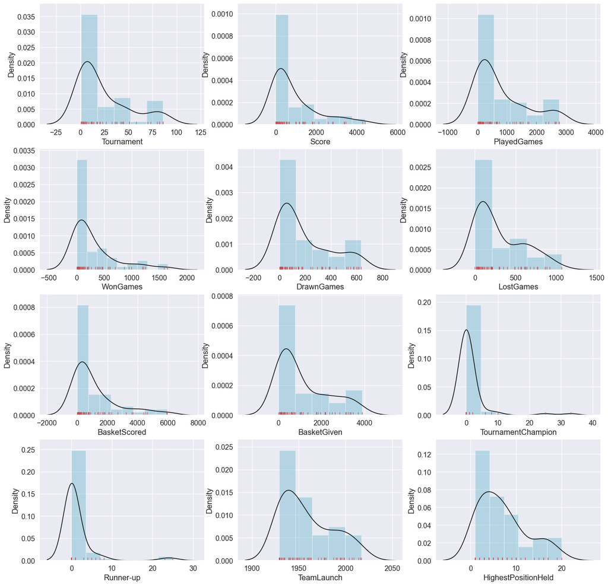

```python
# Check for distribution skewness
attrs = ['Tournament','Score','PlayedGames','WonGames','DrawnGames','LostGames','BasketScored','BasketGiven','TournamentChampion','Runner-up','TeamLaunch','HighestPositionHeld']
plt.figure(figsize=(20,20))
index = 1
for col in basketball[attrs]:
    plt.subplot(4,3,index)
    sns.distplot(basketball[col], rug=True, kde=True,
                 rug_kws={"color": "r"},
                 kde_kws={"color": "k"},
                 hist_kws={"color": "c"})
    index += 1
```

```
(array([ 0,  1,  2,  3,  4,  5,  6,  7,  8,  9, 10, 11, 12, 13, 14, 15, 16,
        17, 18, 19, 20, 21, 22, 23, 24, 25, 26, 27, 28, 29, 30, 31, 32, 33,
        34, 35, 36, 37, 38, 39, 40, 41, 42, 43, 44, 45, 46, 47, 48, 49, 50,
        51, 52, 53, 54, 55, 56, 57, 58, 59, 60]),
 [Text(0, 0, 'Team 1'),
```

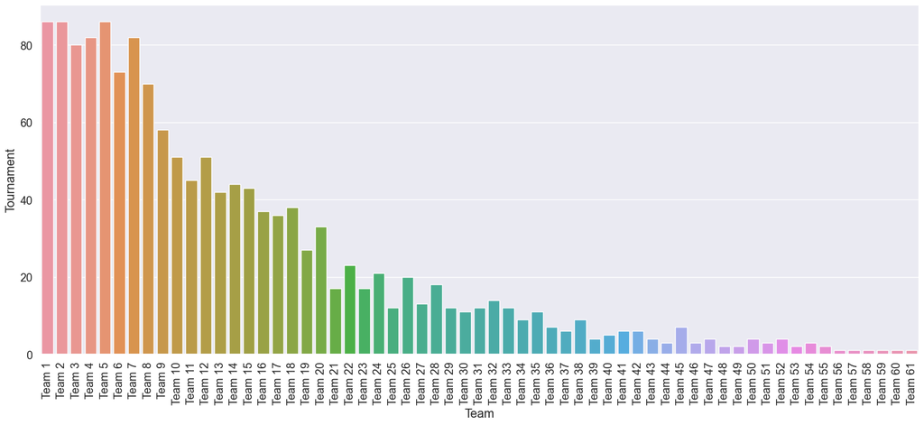

```python
# No of tournaments played by teams
plt.figure(figsize=(20,8))
sns.barplot(basketball['Team'], basketball['Tournament'])
plt.xticks(rotation=90)
```

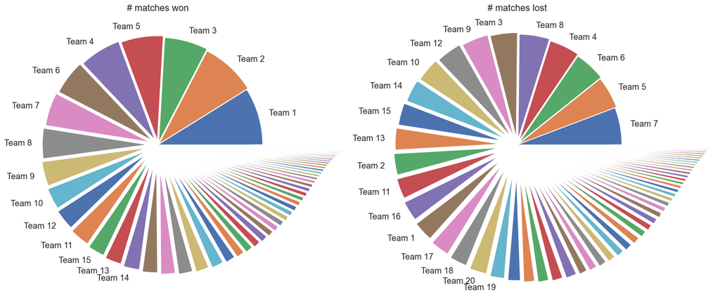

```python
# No of matches won/lost by teams
plt.figure(figsize=(20,8))
plt.subplot(1,2,1)
bb = basketball[['Team','WonGames']].sort_values(by="WonGames", ascending=False)
plot = plt.pie(bb['WonGames'], labels=list(bb['Team'][:15]) + [str()] * (len(bb)-15), explode=[0.015*x for x in range(len(bb))])
plt.title('# matches won')
plt.subplot(1,2,2)
bb = basketball[['Team','LostGames']].sort_values(by="LostGames", ascending=False)
plot = plt.pie(bb['LostGames'], labels=list(bb['Team'][:20]) + [str()] * (len(bb)-20), explode=[0.015*x for x in range(len(bb))])
plt.title('# matches lost')
```

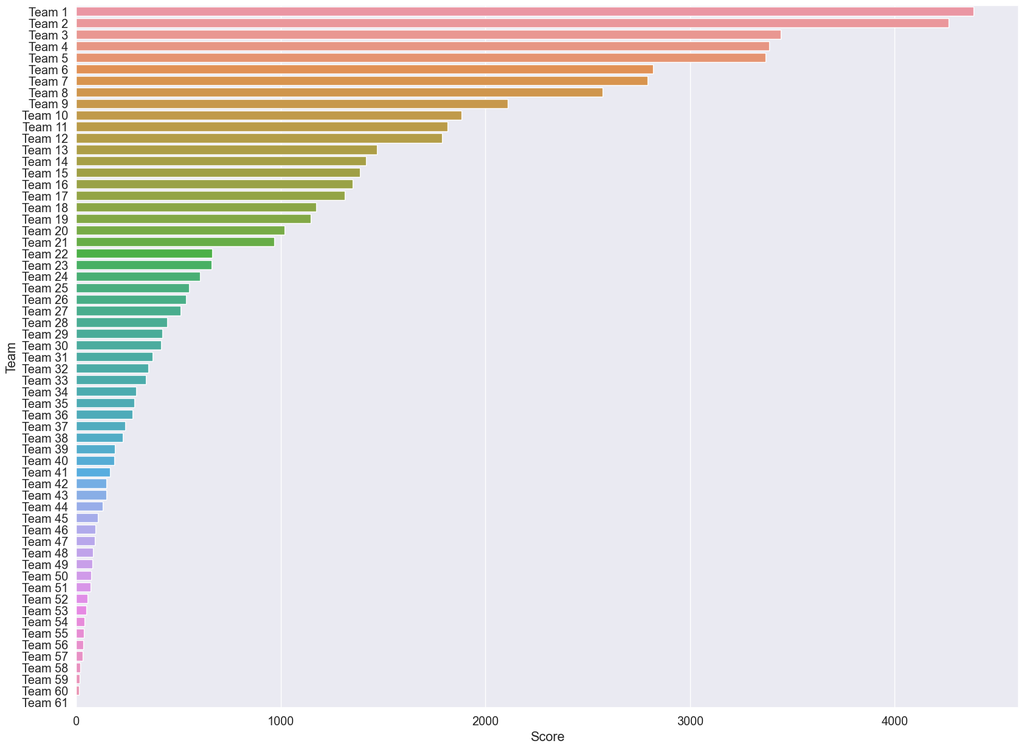

```python
# Scores of the teams
plt.figure(figsize=(20,15))
sns.barplot(basketball['Score'], basketball['Team'], orient='h')
```

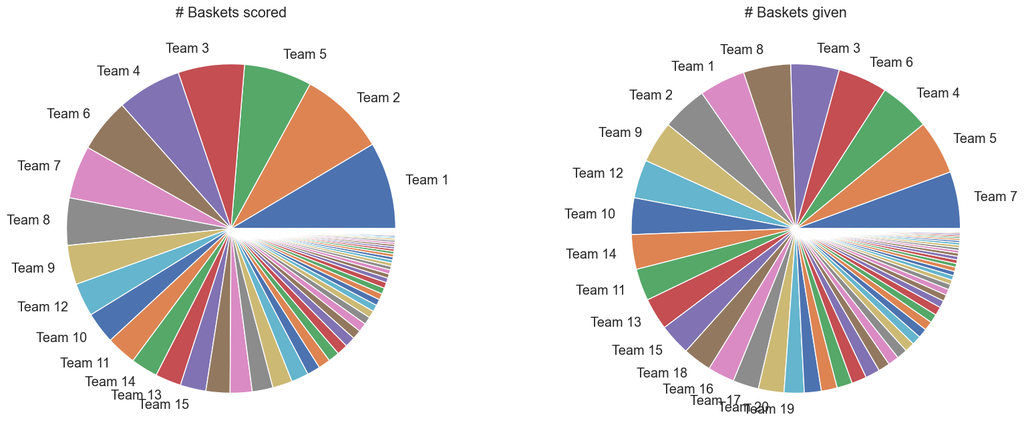

```python
# No of baskets scored/given by teams
plt.figure(figsize=(20,8))
plt.subplot(1,2,1)
bb = basketball[['Team','BasketScored']].sort_values(by="BasketScored", ascending=False)
plot = plt.pie(bb['BasketScored'], labels=list(bb['Team'][:15]) + [str()] * (len(bb)-15))
plt.title('# Baskets scored')
plt.subplot(1,2,2)
bb = basketball[['Team','BasketGiven']].sort_values(by="BasketGiven", ascending=False)
plot = plt.pie(bb['BasketGiven'], labels=list(bb['Team'][:20]) + [str()] * (len(bb)-20))
plt.title('# Baskets given')
```

```
(array([ 0,  1,  2,  3,  4,  5,  6,  7,  8,  9, 10, 11, 12]),
 [Text(0, 0, 'Team 2'),
```

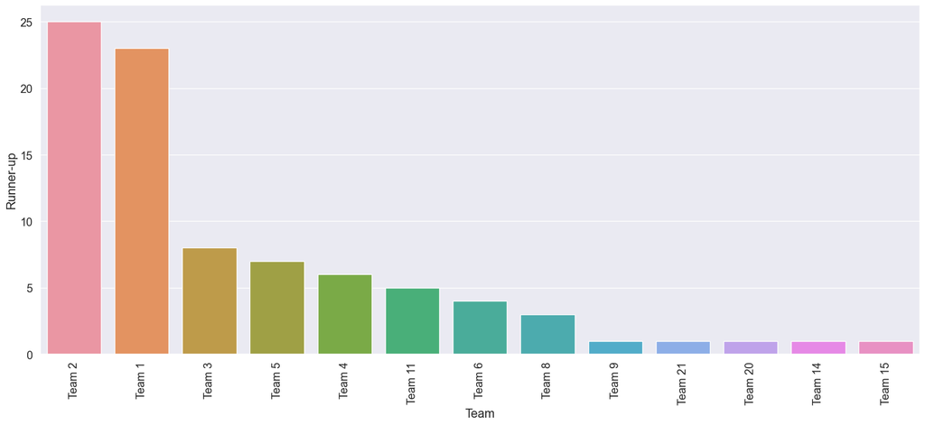

```python
# The most runner-up
plt.figure(figsize=(20,8))
bb = basketball[['Team','Runner-up']].sort_values(by="Runner-up", ascending=False).where(lambda x: x["Runner-up"] > 0)
sns.barplot(bb['Team'], bb['Runner-up'])
plt.xticks(rotation=90)
```

Bivariate Analysis - Relationship between various features

Multivariate Analysis - Pairwise relatioship of all features

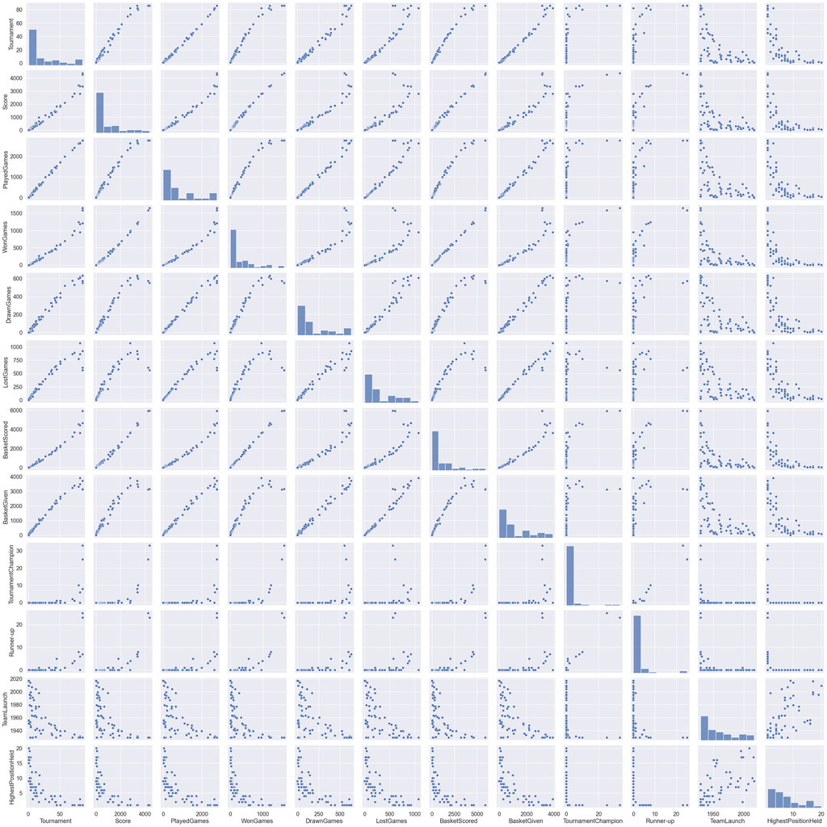

```python
# Pairwise relationship
sns.pairplot(basketball[attrs])
```

Comments Pair plot is built on two basic figures, the histogram and the scatter plot. The histogram on the diagonal allows us to see the distribution of a single variable while the scatter plots on the upper and lower triangles show the relationship between two variables.

Observations

Please include any improvements or suggestions to the association management onquality, quantity, variety, velocity, veracity etc. on the data points collected by theassociation to perform a better data analysis in future. Improvements

1. It is not evident from the data that which teams are already in contract withcompetetiors. This would have helped to eliminate these teams fromperformance evaluation
2. It is not evident from the data how teams are performing recently. This wouldhave helped to evalauate the recent team performance correctly.

# Part C

```python
# Import all the libraries needed to load the dataset and visualize it
import numpy as np
import pandas as pd
import matplotlib.pyplot as plt
import seaborn as sns
```

```python
# Configure for any default setting of any library
%matplotlib inline
sns.set(style='darkgrid', palette='deep', font='sans-serif', font_scale=1.3, color_codes=True)
```

```python
mydata = pd.read_csv('DS+-+Part3+-+CompanyX_EU (1).csv')
```

```python
mydata.head()
```

|  | Startup | Product | Funding | Event | Result | OperatingState |
| --- | --- | --- | --- | --- | --- | --- |
| 0 | 2600Hz | 2600hz.com | NaN | Disrupt SF 2013 | Contestant | Operating |
| 1 | 3DLT | 3dlt.com | $630K | Disrupt NYC 2013 | Contestant | Closed |
| 2 | 3DPrinterOS | 3dprinteros.com | NaN | Disrupt SF 2016 | Contestant | Operating |
| 3 | 3Dprintler | 3dprintler.com | $1M | Disrupt NY 2016 | Audience choice | Operating |
| 4 | 42 Technologies | 42technologies.com | NaN | Disrupt NYC 2013 | Contestant | Operating |

```python
mydata.tail()
```

|  | Startup | Product | Funding | Event | Result | OperatingState |
| --- | --- | --- | --- | --- | --- | --- |
| 657 | Zivity | zivity.com | $8M | TC40 2007 | Contestant | Operating |
| 658 | Zmorph | zmorph3d.com | $1M | - | Audience choice | Operating |
| 659 | Zocdoc | zocdoc.com | $223M | TC40 2007 | Contestant | Operating |
| 660 | Zula | zulaapp.com | $3.4M | Disrupt SF 2013 | Audience choice | Operating |
| 661 | Zumper | zumper.com | $31.5M | Disrupt SF 2012 | Finalist | Operating |

```python
mydata.info()
```

```
<class 'pandas.core.frame.DataFrame'>
RangeIndex: 662 entries, 0 to 661
Data columns (total 6 columns):
 #   Column          Non-Null Count  Dtype
---  ------          --------------  -----
 0   Startup         662 non-null    object
 1   Product         656 non-null    object
 2   Funding         448 non-null    object
 3   Event           662 non-null    object
 4   Result          662 non-null    object
 5   OperatingState  662 non-null    object
dtypes: object(6)
memory usage: 31.2+ KB
```

```python
mydata.shape
```

```
(662, 6)
```

```python
mydata.describe()
```

|  | Startup | Product | Funding | Event | Result | OperatingState |
| --- | --- | --- | --- | --- | --- | --- |
| count | 662 | 656 | 448 | 662 | 662 | 662 |
| unique | 662 | 656 | 240 | 26 | 5 | 4 |
| top | 2600Hz | 2600hz.com | $1M | TC50 2008 | Contestant | Operating |
| freq | 1 | 1 | 17 | 52 | 488 | 465 |

```python
mydata.isnull().sum()
```

[output not shown]

```python
mydata = mydata.dropna(subset=['Funding'])
```

```python
def convertFundingToNumerical (x):
    if type(x) == float or type(x) == int:
        return x
    if 'K' in x:
        if len(x) > 1:
            x = x.replace('$', '')
            return float(x.replace('K', '')) * 1000
        return 1000.0
    if 'M' in x:
        if len(x) > 1:
            x = x.replace('$', '')
            return float(x.replace('M', '')) * 1000000
        return 1000000.0
    if 'B' in x:
        x = x.replace('$', '')
        return float(x.replace('B', '')) * 1000000000
    return 0.0
```

```python
mydata['Funding'] = mydata['Funding'].apply(convertFundingToNumerical)
mydata['Funding'] = pd.to_numeric(mydata['Funding'])
```

```python
mydata.describe()
```

|  | Funding |
| --- | --- |
| count | 4.480000e+02 |
| mean | 1.718237e+07 |
| std | 9.028540e+07 |
| min | 5.000000e+03 |
| 25% | 7.457500e+05 |
| 50% | 2.250000e+06 |
| 75% | 9.425000e+06 |
| max | 1.700000e+09 |

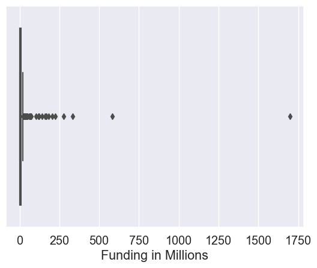

```python
sns.boxplot(x= mydata['Funding'] / 1000000)
plt.xlabel("Funding in Millions")
plt.show()
```

```python
# Get the lower fence from the box plot
q1 = mydata['Funding'].quantile(0.25)
q3 = mydata['Funding'].quantile(0.75)
iqr = q3 - q1
lower_fence = q1 - 1.5 * iqr
print(lower_fence)
```

```
-12273125.0
```

```python
# Check number of outliers greater than upper fence.
upper_fence= q3 + 1.5 * iqr
mydata[mydata['Funding'] > upper_fence].shape
```

```
(60, 6)
```

```python
# • Drop the values that are greater than upper fence.
mydata = mydata[mydata["Funding"] <= upper_fence]
mydata.shape
```

```
(388, 6)
```

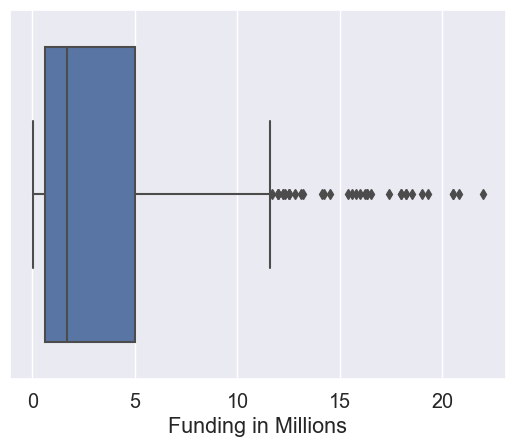

```python
# Plot the box plot after dropping the values.
sns.boxplot(x= mydata['Funding'] / 1000000)
plt.xlabel("Funding in Millions")
plt.show()
```

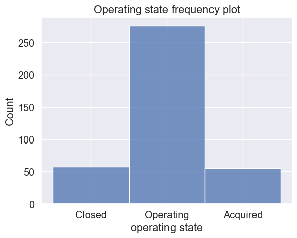

```python
# Check frequency of the OperatingState features classes
sns.histplot(mydata['OperatingState'])
plt.title("Operating state frequency plot")
plt.xlabel("operating state")
plt.show()
```

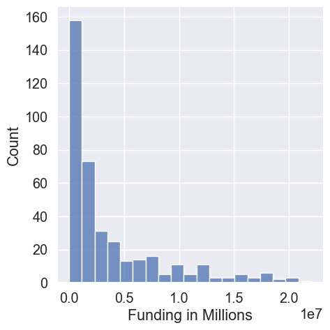

```python
# Plot a distribution plot for Funds in million.
sns.displot(mydata['Funding'])
plt.xlabel("Funding in Millions")
plt.show()
```

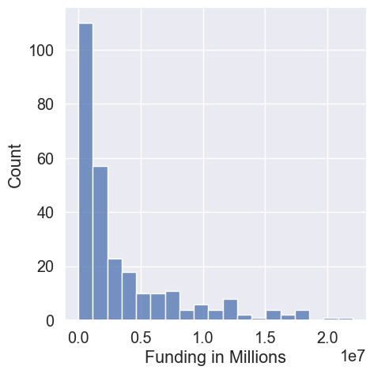

```python
# Plot distribution plots for companies still operating
comp_operational = mydata[mydata['OperatingState'] == "Operating"]
sns.displot(comp_operational['Funding'])
plt.xlabel("Funding in Millions")
plt.show()
```

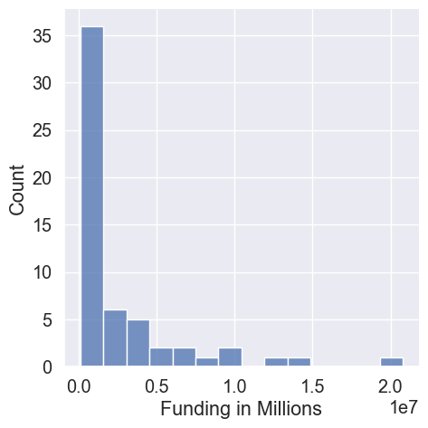

```python
# Plot distribution plots for companies that closed.
comp_closed = mydata[mydata['OperatingState'] == "Closed"]
sns.displot(comp_closed['Funding'])
plt.xlabel("Funding in Millions")
plt.show()
```

Is there any significant difference between Funds raised bycompanies that are still operating vs companies that closed down?

Write the null hypothesis and alternative hypothesis.  
H0 : There is no significant difference between funds raised by companies that ate still operating vs companies that closed down.  
Ha : There is significant difference between funds raised by companies that ate still operating vs companies that closed down

Test for significance and conclusion

```python
tstat,pval = stats.ttest_ind(comp_operational['Funding'],comp_closed['Funding'])
if pval < 0.05:
 print(f'With a p-value of{round( pval,4)} the difference is significant.aka | We reject the null | Hence we conclude There is significant difference between funds raised by companies that ate still operating vs companies that closed down.' )
else:
 print(f'With a p-value of{round(pval,4)}the difference is not significant.aka|We fail to reject the null|Hence we conclude There is no significant difference between funds raised by companies that ate still operating vs companies that closed down.')
```

```
With a p-value of0.2084the difference is not significant.aka|We fail to reject the null|Hence we conclude There is no significant difference between funds raised by companies that ate still operating vs companies that closed down.
```

```python
# Make a copy of the original data frame.
comp_data_org =mydata.copy()
```

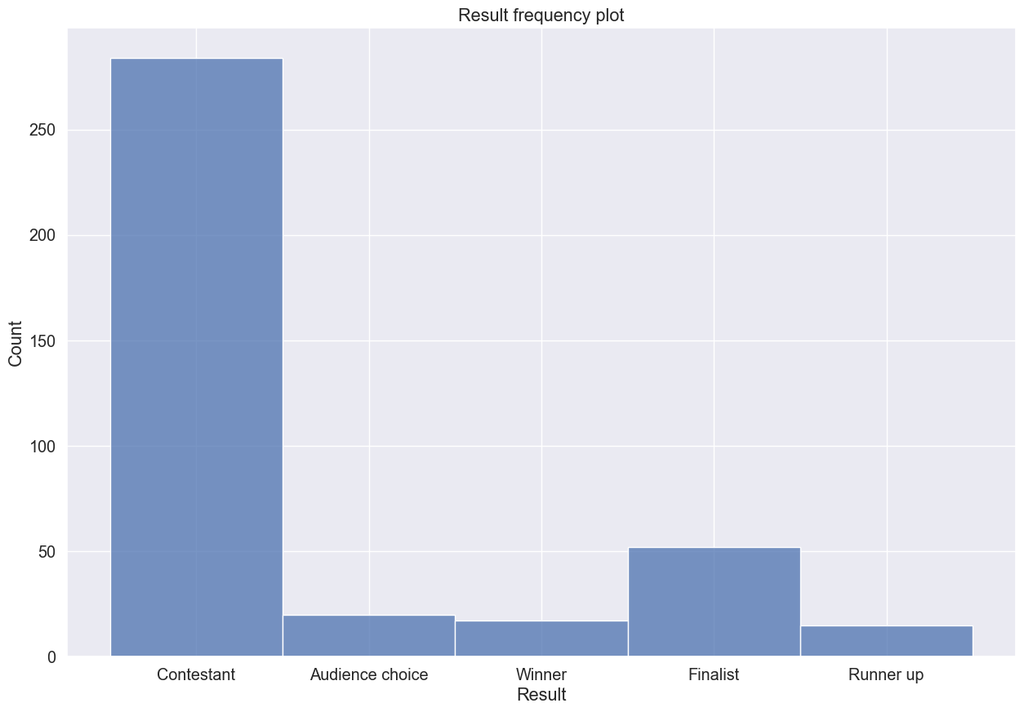

```python
# Check frequency distribution of Result variableplt.figure(figsize=(15,10))sns.histplot(comp_data_org['Result'])
plt.figure(figsize=(15,10))
sns.histplot(comp_data_org['Result'])
plt.title("Result frequency plot")
plt.xlabel("Result")
plt.show()
```

Calculate percentage of winners that are still operating and percentage of contestantsthat are still operating

```python
#Calculate the no of winners and contestants from the company data which are stiloperational
operational_df = comp_data_org[comp_data_org["OperatingState"] == "Operating"]
operational_df_winners = operational_df[operational_df['Result'] == 'Winner'].count()[0]
operational_df_contestants = operational_df[operational_df['Result'] =='Contestant'].count()[0]
total_winners = comp_data_org[comp_data_org['Result'] == 'Winner'].count()[0]
total_contestants = comp_data_org[comp_data_org['Result'] == 'Contestant'].count()[0]
per_winner_operational = (operational_df_winners/total_winners)* 100
per_contestant_operational = (operational_df_contestants/total_contestants)* 100
print(f"percentage of winners who are still operating {round(per_winner_operational,2)}")
print(f"percentage of contenstants who are still operating{round(per_contestant_operational, 2)}")
```

```
percentage of winners who are still operating 70.59
percentage of contenstants who are still operating68.66
```

Write your hypothesis comparing the proportion of companies thatare operating between winners and contestants:  
Write the null hypothesis and alternative hypothesis.

H0: There is no significant difference between the proportion of companies that areoperating between winners and contestants.  
Ha: There is significant difference between the proportion of companies that areoperating between winners and contestants.

```python
from statsmodels.stats.proportion import proportions_ztest
stat,pval =proportions_ztest([operational_df_winners,operational_df_contestants],[total_winners,total_contestants])
if pval < 0.05:
    print(f'With a p-value of {round(pval,4)} the difference is significant. aka |Wereject the null| Hence we conclude There is significant difference between theproportion of companies that are operating between winners and contestants')
else:
    print(f'With a p-value of {round(pval,4)} the difference is not significant. aka |We fail to reject the null| Hence we conclude There is no significant differencebetween the proportion of companies that are operating between winners   andcontestants.')
```

```
With a p-value of 0.8678 the difference is not significant. aka |We fail to reject the null| Hence we conclude There is no significant differencebetween the proportion of companies that are operating between winners   andcontestants.
```

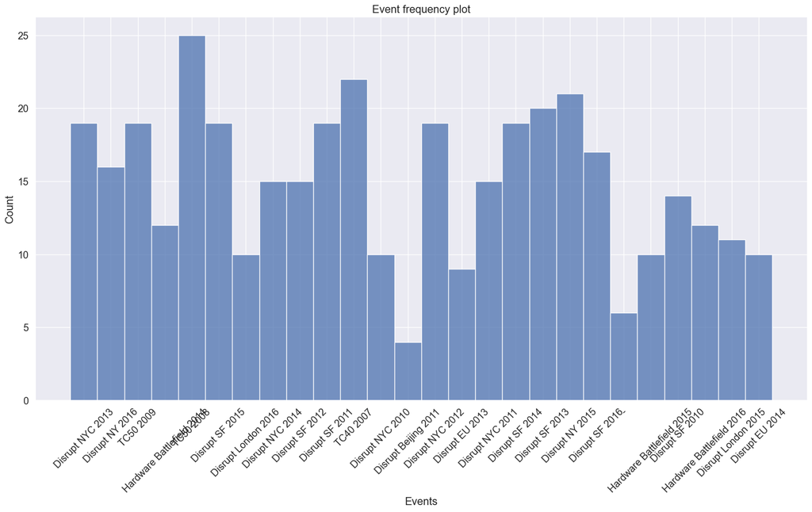

```python
# Check distribution of the Event variable
plt.figure(figsize=(20,10))
sns.histplot(comp_data_org['Event'])
plt.xticks(rotation=45)
plt.title("Event frequency plot")
plt.xlabel("Events")
plt.show()
```

```python
# Filter events data with 'Disrupt' keyword
events_data =comp_data_org[comp_data_org["Event"].str.contains('Disrupt')].copy()
```

```python
# Split event data to get event name, event location, and event year.
events_data[['EventName','EventLocation','EventYear']] = events_data['Event'].str.split(' ',expand=True)
```

```python
# Replace "-" character to NAN
events_data['EventYear'] = events_data['EventYear'].replace('-', np.nan)
```

```python
events_data["EventYear"] = pd.to_numeric(events_data["EventYear"])
```

```python
events_data["EventYear"].describe()
```

```
count     282.000000
mean     2013.329787
std         1.892418
min      2010.000000
25%      2012.000000
50%      2013.000000
75%      2015.000000
max      2016.000000
Name: EventYear, dtype: float64
```

```python
# Select only the Event that has disrupt keyword from 2013 onwards
events_data = events_data[events_data["EventYear"] >= 2013]
```

Write and perform your hypothesis along with significance testcomparing the funds raised by companies across NY, SF and EUevents from 2013 onwards: Write the null hypothesis and alternative hypothesis.

H0 : There is no significant difference between the funds raised by companies across NY , SF and EU events from 2013 onwards .

Ha : There is significant difference between the funds raised by companies across NY , SF and EU events from 2013 onwards .

```python
events_data_ny = events_data[events_data['EventLocation'] == 'NY']
events_data_sf = events_data[events_data['EventLocation'] == 'SF']
events_data_eu = events_data[events_data['EventLocation'] == 'EU']
```

```python
stats, pval = stats.f_oneway(events_data_ny['Funding'], events_data_sf['Funding'],
events_data_eu['Funding'])

if pval<0.05:

 print (f' With a p-value of { round ( pval , 4 ) } the difference is significant . aka | We reject the null | hence we can conclude that There is significant difference between the funds raised by companies across NY , SF and EU events from 2013 onwards . ')
else:

 print (f' With a p-value of { round ( pval , 4 ) } the difference is not significant . aka | We fail to reject the null | hence we can conclude that There is no significant difference between the funds raised by companies across NY , SF and EU events from 2013 onwards ' )
```

```
 With a p-value of 0.6302 the difference is not significant . aka | We fail to reject the null | hence we can conclude that There is no significant difference between the funds raised by companies across NY , SF and EU events from 2013 onwards
```

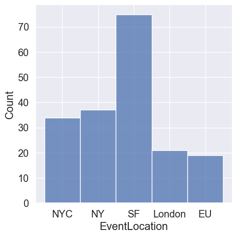

```python
# Plot the distribution plot comparing the 3 city events
sns.displot ( events_data , x = "EventLocation")
plt.show ( )
```

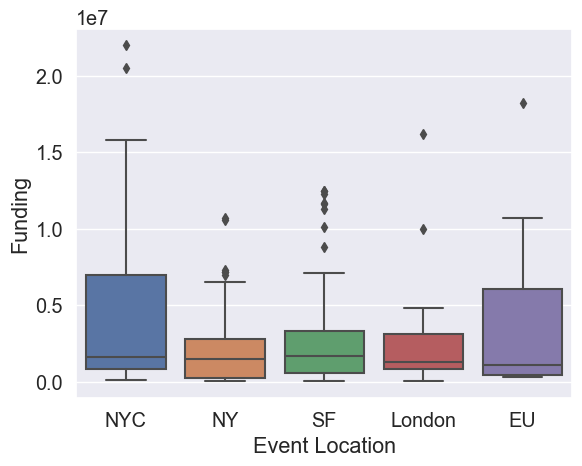

```python
# Plot the distribution plot comparing the 3 city events
sns.boxplot(x="EventLocation", y="Funding", data=events_data)
plt.xlabel("Event Location")
plt.show()
```

Write your observations on improvements or suggestions on quality,quantity, variety, velocity, veracity etc. on the data points collectedto perform a better data analysis.  
Improvements

1. The data has lot of missing values for Funding column. It is not known ifcompany is not funded or data is missing
2. The data is not uniformly scaled. Data is provided in K, M etc.
3. The data has "Audience Choice" as value for Result. It is not known if these aresame as "Winner".